# Final Report: Prediction of Survival of Passengers in Titanic with other messages

王韵倫

2017.1.31 [278期]

*Final Report為R程式設計班[278期]期末作業。本次報告將以線上Toy dataset：[Titanic: Machine Learning from Disaster](https://www.kaggle.com/c/titanic/data)內，去除乘客存活記錄之[test](https://www.kaggle.com/c/titanic/download/test.csv)資料，經資料匯入與觀察、資料整理：處理缺失數據（Missing values）、建立預測模型、產生預測值、整理預測值、檢查資料與上傳，以及最後回傳預測結果準確率，完成資料分析習作，並以GitHub Page呈現。*

## 1. 資料匯入與觀察

### 1.1 匯入線上Toy dataset：test

以`read.csv()`讀取位於url遠端的.csv檔「test」，並指派該資料框為「Test」。

```r
url <- "https://storage.googleapis.com/py_ds_basic/kaggle_titanic_test.csv"
Test <- read.csv(url)
```

此步驟完成後，已將線上資料讀入RStudio，但此時並不知道此資料有多少待測筆數或任何結構，貿然直接輸入`Test`叫喚資料也許會洗版Console…，故需以部分函數對資料進行觀察。

### 1.2 資料觀察

#### 1.2.1 `str()`與`summary()`

首先，必需知道Test資料框內組成資料的「結構」，因此使用`str()`查看。

```r
str(Test)
```

```
## 'data.frame':    418 obs. of  11 variables:
##  $ PassengerId: int  892 893 894 895 896 897 898 899 900 901 ...
##  $ Pclass     : int  3 3 2 3 3 3 3 2 3 3 ...
##  $ Name       : Factor w/ 418 levels "Abbott, Master. Eugene Joseph",..: 210 409 273 414 182 370 85 58 5 104 ...
##  $ Sex        : Factor w/ 2 levels "female","male": 2 1 2 2 1 2 1 2 1 2 ...
##  $ Age        : num  34.5 47 62 27 22 14 30 26 18 21 ...
##  $ SibSp      : int  0 1 0 0 1 0 0 1 0 2 ...
##  $ Parch      : int  0 0 0 0 1 0 0 1 0 0 ...
##  $ Ticket     : Factor w/ 363 levels "110469","110489",..: 153 222 74 148 139 262 159 85 101 270 ...
##  $ Fare       : num  7.83 7 9.69 8.66 12.29 ...
##  $ Cabin      : Factor w/ 77 levels "","A11","A18",..: 1 1 1 1 1 1 1 1 1 1 ...
##  $ Embarked   : Factor w/ 3 levels "C","Q","S": 2 3 2 3 3 3 2 3 1 3 ...
```

`str()`可以得知組成資料之稱呼、筆數、類型及記錄概況。在Test中，總共有418列待預測乘客總數，11個欄位記錄乘客的不同資訊（ex：ID、Name、Sex、Age、Fare…等）。此外，亦可以得知每種資訊屬於哪一種資料類型（ex：integer、factor、numeric）。  
不過，若想知道組成資料的「統計資訊」，就得使用`summary()`。

```r
summary(Test)
```

```
##   PassengerId         Pclass
##  Min.   : 892.0   Min.   :1.000
##  1st Qu.: 996.2   1st Qu.:1.000
##  Median :1100.5   Median :3.000
##  Mean   :1100.5   Mean   :2.266
##  3rd Qu.:1204.8   3rd Qu.:3.000
##  Max.   :1309.0   Max.   :3.000
##
##                                         Name         Sex
##  Abbott, Master. Eugene Joseph            :  1   female:152
##  Abelseth, Miss. Karen Marie              :  1   male  :266
##  Abelseth, Mr. Olaus Jorgensen            :  1
##  Abrahamsson, Mr. Abraham August Johannes :  1
##  Abrahim, Mrs. Joseph (Sophie Halaut Easu):  1
##  Aks, Master. Philip Frank                :  1
##  (Other)                                  :412
##       Age            SibSp            Parch             Ticket
##  Min.   : 0.17   Min.   :0.0000   Min.   :0.0000   PC 17608:  5
##  1st Qu.:21.00   1st Qu.:0.0000   1st Qu.:0.0000   113503  :  4
##  Median :27.00   Median :0.0000   Median :0.0000   CA. 2343:  4
##  Mean   :30.27   Mean   :0.4474   Mean   :0.3923   16966   :  3
##  3rd Qu.:39.00   3rd Qu.:1.0000   3rd Qu.:0.0000   220845  :  3
##  Max.   :76.00   Max.   :8.0000   Max.   :9.0000   347077  :  3
##  NA's   :86                                        (Other) :396
##       Fare                     Cabin     Embarked
##  Min.   :  0.000                  :327   C:102
##  1st Qu.:  7.896   B57 B59 B63 B66:  3   Q: 46
##  Median : 14.454   A34            :  2   S:270
##  Mean   : 35.627   B45            :  2
##  3rd Qu.: 31.500   C101           :  2
##  Max.   :512.329   C116           :  2
##  NA's   :1         (Other)        : 80
```

`summary()`會對組成資料進行概略統計或計數。此步驟除了藉由統計結果觀察資料分布外，需確認各欄位總筆數並觀察有無資料記錄不全處（“Missing values”），通常記錄為「NA（Not Available）」或不尋常之空格。在Test中，發現Age欄位有86個NA，Fare欄位有1個NA。

## 2. 資料整理：處理缺失數據（Missing values）

根據[R筆記–(10)遺漏值處理(Impute Missing Value)](https://rpubs.com/skydome20/R-Note10-Missing_Value)敘述，常用來處理資料框內缺失數據（通常記錄為NA）的方法為：  
(1). 直接刪除含缺失數據之樣本。  
(2). 以平均數、中位數、眾數、第一四分位數…等統計上可以代表樣本群之數值來填補。  
(3). K-Nearest Neighbours(KNN)法進行填補。  
(4). Multivariate Imputation via Chained Equations (MICE)法進行填補。  
由上課練習過(1)、(2)之經驗可得知，(1)對預測之負面影響為減少觀測總樣本數，使含有NA之樣本的其他有記錄觀測值無法貢獻於預測上；(2)之負面影響則是，統計數值或許和原始應位於NA位置的值相差甚遠，而無法代表之。上述影響都可能進一步造成預測失誤，尤其當NA值眾多時。

因此，「如何藉由記錄完整之訊息，推估NA可能值」便成為其他填補NA方法發展的概念。  
本次報告將使用(3)、(4)進行NA填補練習，並比較兩種方式是否影響預測結果。

### 2.1 K-Nearest Neighbours(KNN)

#### 2.1.1 原理概述

參考KNN的[Wiki](https://en.wikipedia.org/wiki/K-nearest_neighbors_algorithm)。  
另外，引述[R筆記–(10)遺漏值處理(Impute Missing Value)](https://rpubs.com/skydome20/R-Note10-Missing_Value)對KNN概念之描述：

> 現在有一群學生的成績，包含國文、數學、自然，但老師不小心弄丟小明的國文考卷，於是小明的「國文」分數是遺漏值。如果在不重考的狀況下，我們要給小明一個分數，該怎麼做？  
> KNN的概念告訴我們，應該先看小明「數學和自然」的分數，看和哪些同學(K位)很相近，然後再拿那些同學(K位)的國文分數，取平均或加權平均(或是其他手法)後，當作小明的分數來填補。  
> 一句話概括：「就是找和自己很像的K個鄰居，然後從他們身上複製自己所沒有的東西。」

#### 2.1.2 實際操作

匯入Package「DMwR」，使用`knnImputation()`填補NA，並指派受KNN處理過的新資料框為「KNN_Test」。  
附帶一提，[DMwR使用說明](https://cran.r-project.org/web/packages/DMwR/DMwR.pdf)中，`knnImputation()`之Arguments為5個。在此則不更改任何預設值進行填補。

```r
library("DMwR", lib.loc="~/R/win-library/3.3")
KNN_Test <- knnImputation(Test)
```

觀察KNN_Test資料框內NA是否填補成功。

```r
summary(KNN_Test)
```

```
##   PassengerId         Pclass
##  Min.   : 892.0   Min.   :1.000
##  1st Qu.: 996.2   1st Qu.:1.000
##  Median :1100.5   Median :3.000
##  Mean   :1100.5   Mean   :2.266
##  3rd Qu.:1204.8   3rd Qu.:3.000
##  Max.   :1309.0   Max.   :3.000
##
##                                         Name         Sex
##  Abbott, Master. Eugene Joseph            :  1   female:152
##  Abelseth, Miss. Karen Marie              :  1   male  :266
##  Abelseth, Mr. Olaus Jorgensen            :  1
##  Abrahamsson, Mr. Abraham August Johannes :  1
##  Abrahim, Mrs. Joseph (Sophie Halaut Easu):  1
##  Aks, Master. Philip Frank                :  1
##  (Other)                                  :412
##       Age            SibSp            Parch             Ticket
##  Min.   : 0.17   Min.   :0.0000   Min.   :0.0000   PC 17608:  5
##  1st Qu.:22.00   1st Qu.:0.0000   1st Qu.:0.0000   113503  :  4
##  Median :27.00   Median :0.0000   Median :0.0000   CA. 2343:  4
##  Mean   :29.45   Mean   :0.4474   Mean   :0.3923   16966   :  3
##  3rd Qu.:36.00   3rd Qu.:1.0000   3rd Qu.:0.0000   220845  :  3
##  Max.   :76.00   Max.   :8.0000   Max.   :9.0000   347077  :  3
##                                                    (Other) :396
##       Fare                     Cabin     Embarked
##  Min.   :  0.000                  :327   C:102
##  1st Qu.:  7.896   B57 B59 B63 B66:  3   Q: 46
##  Median : 14.454   A34            :  2   S:270
##  Mean   : 35.765   B45            :  2
##  3rd Qu.: 31.500   C101           :  2
##  Max.   :512.329   C116           :  2
##                    (Other)        : 80
```

由此summary結果可發現，原先Test資料框內Age與Fare欄位所有NA被填補完成，即KNN_Test資料框所有欄位皆有418列觀測值且無NA。

### 2.2 Multivariate Imputation via Chained Equations (MICE)

#### 2.2.1 原理概述

參考ImputationWiki內的*2.2 Multiple imputation*。  
同樣引述[R筆記–(10)遺漏值處理(Impute Missing Value)](https://rpubs.com/skydome20/R-Note10-Missing_Value)對MICE概念之描述：

> 概念很簡單：現在我們有欄位V1,V2,V3……Vn，每個欄位裡面都有遺漏值。  
> 當我們要填補V1的遺漏值時，就先把V2,V3……Vn的欄位當作自變數(X)，把V1當作應變數(Y)，並且進行建模，然後用預測的結果來填補V1的遺漏值。  
> 同理，針對V2，就用V1,V3……Vn建模，然後用預測的結果來填補V2的遺漏值。  
> (由於這個函式，背後有使用Gibbs sampling(一種抽樣手法)。所以，即使使用某個模型進行遺漏值填補，也會因為抽樣手法，造成最後填補的結果有些許不同)

#### 2.2.2 實際操作

匯入Package「mice」，使用`mice()`填補NA，並指派受mice處理過的新資料框為「MICE_Test」。  
`mice()`詳細各Arguments介紹可參考這篇[RDocumentation](https://www.rdocumentation.org/packages/mice/versions/2.25/topics/mice)。看起來比KNN複雜許多 @@a，總之先練習操作看看。  
按照「R筆記–(10)遺漏值處理(Impute Missing Value)」上程式步驟如下：

MICE_Test <- mice(Test,  
m = 3, # 產生三個被填補好的資料表  
maxit = 50, # max iteration  
method = “cart”, # 使用CART決策樹，進行遺漏值預測  
seed = 188) # set.seed()，令抽樣每次都一樣

Dear，如果就這樣開始跑程式，不管是在Console還是Knit，你就會發現電腦 **動.不.了.啦！！！**  
雖然尚未詳細看完和理解所有文獻，但有點近似此意思：電腦不動並不是當機，而是因為`mice()`在填補NA時使用的建模原理會牽扯所有其他記錄完整的觀測值進行運算…嗯！光用想的就算不完，網路上查到還有苦主擺了一個晚上仍未果，科科。  
所以，我們改以下步驟，**先約束建模用的觀測值數目，再完成填補**。

##### 2.2.2.1 約束建模所需觀測值

首先，先**人工**判斷那些觀測值種類與Age、Fare之NA可能值預測較相關。在此認定流水號類型記錄值–「PassenerId」、「Name」、「Ticket」、「Cabin」–應和預測無關，故建立一字串型向量，以便之後函數使用。

```r
exclude_Test <- c("PassenerId","Name","Ticket","Cabin")
```

##### 2.2.2.2 使用`mice()`

匯入Package「mice」，使用`mice()`對Age、Fare之NA進行可能值運算，並將結果指派為「pre_MICE_Test」。

```r
library("mice", lib.loc="~/R/win-library/3.3")
pre_MICE_Test <- mice(Test,
                      pred=quickpred(Test, minpuc=0.9, exclude = exclude_Test),
                      seed = 87) # 使用班級幸運數字固定每次抽樣預測之結果XD
```

其中，`quickpred()`屬於mice package，其計算兩種觀測變數間（ex: Name vs. Age）是否相關並將結果以`predictorMatrix`呈現。而該Matrix可直接作為`mice()`Argument「predictorMatrix（簡稱“pred”）」之值，用來約束`mice()`建模運算NA時，考量的觀測值種類數。  
其他Arguments本次使用到minpuc、exclude。exclude即直接設定不考量的觀測值種類；minpuc則指「the minimum threshold(s) for the proportion of usable cases」，範例顯示，一般用在`mice()`給0.25，此給0.9。  
呼叫「pre_MICE_Test」及使用`class()`，觀察其結果含哪些資訊：

```r
pre_MICE_Test
```

```
## Multiply imputed data set
## Call:
## mice(data = Test, predictorMatrix = quickpred(Test, minpuc = 0.9,
##     exclude = exclude_Test), seed = 87)
## Number of multiple imputations:  5
## Missing cells per column:
## PassengerId      Pclass        Name         Sex         Age       SibSp
##           0           0           0           0          86           0
##       Parch      Ticket        Fare       Cabin    Embarked
##           0           0           1           0           0
## Imputation methods:
## PassengerId      Pclass        Name         Sex         Age       SibSp
##          ""          ""          ""          ""       "pmm"          ""
##       Parch      Ticket        Fare       Cabin    Embarked
##          ""          ""       "pmm"          ""          ""
## VisitSequence:
##  Age Fare
##    5    9
## PredictorMatrix:
##             PassengerId Pclass Name Sex Age SibSp Parch Ticket Fare Cabin
## PassengerId           0      0    0   0   0     0     0      0    0     0
## Pclass                0      0    0   0   0     0     0      0    0     0
## Name                  0      0    0   0   0     0     0      0    0     0
## Sex                   0      0    0   0   0     0     0      0    0     0
## Age                   0      1    0   0   0     0     0      0    1     0
## SibSp                 0      0    0   0   0     0     0      0    0     0
## Parch                 0      0    0   0   0     0     0      0    0     0
## Ticket                0      0    0   0   0     0     0      0    0     0
## Fare                  0      1    0   1   1     1     1      0    0     0
## Cabin                 0      0    0   0   0     0     0      0    0     0
## Embarked              0      0    0   0   0     0     0      0    0     0
##             Embarked
## PassengerId        0
## Pclass             0
## Name               0
## Sex                0
## Age                1
## SibSp              0
## Parch              0
## Ticket             0
## Fare               1
## Cabin              0
## Embarked           0
## Random generator seed value:  87
```

```r
class(pre_MICE_Test)
```

```
## [1] "mids"
```

pre_MICE_Test屬於`mids`種類之物件，意指「由`mice()`產生的multiply imputed data set」。`mids`內有許多建模運算NA相關資訊（可參考[mice package說明書](https://cran.r-project.org/web/packages/mice/mice.pdf)第41頁），值得一提的是Argument「VisitSequence」，若按照其中數字作為index直接呼叫：

```r
pre_MICE_Test[5]
```

```
## $imp
## $imp$PassengerId
## NULL
##
## $imp$Pclass
## NULL
##
## $imp$Name
## NULL
##
## $imp$Sex
## NULL
##
## $imp$Age
##        1    2    3    4    5
```

[output cut: 105 more lines]

抱歉，我不清楚套入Fare下方數字後，叫出的pre_MICE_Test[9]是做什麼用的 @@|||可以發現NA可能值在Age、Fare欄位之預測結果，而不改任何預設值下，所有NA皆將皆有5次預測結果。但到此步，我們仍尚未選定到底哪一次結果真正去填補NA。

##### 2.2.2.3 使用`complete()`形成NA填補後的資料框

**人工**觀察後，我傾向使用第3組資料。

```r
library("mice", lib.loc="~/R/win-library/3.3")
MICE_Test <- complete(pre_MICE_Test, 3) # 使用第3組NA可能值預測結果
```

觀察MICE_Test資料框內NA是否填補成功。

```r
summary(MICE_Test)
```

```
##   PassengerId         Pclass
##  Min.   : 892.0   Min.   :1.000
##  1st Qu.: 996.2   1st Qu.:1.000
##  Median :1100.5   Median :3.000
##  Mean   :1100.5   Mean   :2.266
##  3rd Qu.:1204.8   3rd Qu.:3.000
##  Max.   :1309.0   Max.   :3.000
##
##                                         Name         Sex
##  Abbott, Master. Eugene Joseph            :  1   female:152
##  Abelseth, Miss. Karen Marie              :  1   male  :266
##  Abelseth, Mr. Olaus Jorgensen            :  1
##  Abrahamsson, Mr. Abraham August Johannes :  1
##  Abrahim, Mrs. Joseph (Sophie Halaut Easu):  1
##  Aks, Master. Philip Frank                :  1
##  (Other)                                  :412
##       Age            SibSp            Parch             Ticket
##  Min.   : 0.17   Min.   :0.0000   Min.   :0.0000   PC 17608:  5
##  1st Qu.:21.00   1st Qu.:0.0000   1st Qu.:0.0000   113503  :  4
##  Median :27.00   Median :0.0000   Median :0.0000   CA. 2343:  4
##  Mean   :29.86   Mean   :0.4474   Mean   :0.3923   16966   :  3
##  3rd Qu.:38.00   3rd Qu.:1.0000   3rd Qu.:0.0000   220845  :  3
##  Max.   :76.00   Max.   :8.0000   Max.   :9.0000   347077  :  3
##                                                    (Other) :396
##       Fare                     Cabin     Embarked
##  Min.   :  0.000                  :327   C:102
##  1st Qu.:  7.896   B57 B59 B63 B66:  3   Q: 46
##  Median : 14.454   A34            :  2   S:270
##  Mean   : 35.561   B45            :  2
##  3rd Qu.: 31.472   C101           :  2
##  Max.   :512.329   C116           :  2
##                    (Other)        : 80
```

由此summary結果可發現，原先Test資料框內Age與Fare欄位所有NA被填補完成，即MICE_Test資料框所有欄位皆有418列觀測值且無NA。

## 3. 預測模型建立與產生預測值

想了解Titanic上不同條件是否會影響乘客存活率，或存活僅只幸運，可以採取填補好NA之其他觀測值欄位，對存活與否進行預測。

### 3.1 預測模型建立：存活與否

本次使用「決策樹（Decision tree）」運算方式進行預測。  
然而，所謂預測模型是指電腦曾經同樣以其他變數對待測變數進行過預測。因此，需要一個有Survived欄位的Titanic資料框給電腦建立預測模型。  
故下述參考課堂流程，讀取相同線上Toy dataset內[train](https://www.kaggle.com/c/titanic/download/train.csv)資料框，直接去除含有NA列數、以眾數「S」填補未記錄上船港口，並轉換Survived欄位記錄值類型為Factor，再指派該資料框為「titanic」。

```r
titanic <- read.csv("https://storage.googleapis.com/2017_ithome_ironman/data/kaggle_titanic_train.csv")
# 直接去除含有NA之列數
titanic <- titanic[complete.cases(titanic), ]
# 以眾數"S"填補未記錄上船港口
titanic$Embarked <- as.character(titanic$Embarked)
titanic$Embarked[titanic$Embarked == ""] <- "S"
titanic$Embarked <- factor(titanic$Embarked)
# 轉換Survived欄位記錄值類型為Factor
titanic$Survived <- factor(titanic$Survived)
# 觀察更動後的titanic
summary(titanic)
```

```
##   PassengerId    Survived     Pclass
##  Min.   :  1.0   0:424    Min.   :1.000
##  1st Qu.:222.2   1:290    1st Qu.:1.000
##  Median :445.0            Median :2.000
##  Mean   :448.6            Mean   :2.237
##  3rd Qu.:677.8            3rd Qu.:3.000
##  Max.   :891.0            Max.   :3.000
##
##                                     Name         Sex           Age
##  Abbing, Mr. Anthony                  :  1   female:261   Min.   : 0.42
##  Abbott, Mr. Rossmore Edward          :  1   male  :453   1st Qu.:20.12
##  Abbott, Mrs. Stanton (Rosa Hunt)     :  1                Median :28.00
##  Abelson, Mr. Samuel                  :  1                Mean   :29.70
##  Abelson, Mrs. Samuel (Hannah Wizosky):  1                3rd Qu.:38.00
##  Adahl, Mr. Mauritz Nils Martin       :  1                Max.   :80.00
##  (Other)                              :708
##      SibSp            Parch                 Ticket         Fare
##  Min.   :0.0000   Min.   :0.0000   347082      :  7   Min.   :  0.00
##  1st Qu.:0.0000   1st Qu.:0.0000   3101295     :  6   1st Qu.:  8.05
##  Median :0.0000   Median :0.0000   347088      :  6   Median : 15.74
##  Mean   :0.5126   Mean   :0.4314   CA 2144     :  6   Mean   : 34.69
##  3rd Qu.:1.0000   3rd Qu.:1.0000   382652      :  5   3rd Qu.: 33.38
##  Max.   :5.0000   Max.   :6.0000   S.O.C. 14879:  5   Max.   :512.33
##                                    (Other)     :679
##          Cabin     Embarked
##             :529   C:130
##  B96 B98    :  4   Q: 28
##  C23 C25 C27:  4   S:556
##  G6         :  4
##  C22 C26    :  3
##  D          :  3
##  (Other)    :167
```

```r
class(titanic$Survived)
```

```
## [1] "factor"
```

`summary()`結果，可以確定titanic資料框沒有NA，且Survived欄位記錄值類型以轉換成Factor。  
接著，匯入Package「rpart」，使用`rpart()`對titanic中的Survived觀測值建立決策樹預測模型。

```r
library("rpart", lib.loc="~/R/win-library/3.3")
rpart_model <- rpart(Survived ~ Pclass + Sex + Age + SibSp + Parch + Fare + Embarked,
                     # "~"前放置待預測變數，後放置想加入預測用的變數，彼此欄位名稱以"+"相連。
                     data = titanic,
                     method = "class")
                     # method = "class"代表請函數判斷待預測之Survived為factor類型。
```

### 3.2 產生預測值

使用Package「rpart」中`predict()`分別對KNN法填補NA後的「KNN_Test」和MICE法的「MICE_Test」兩資料框進行每列Survived欄位可能數值之預測，並指派結果為「KNN_pred」及「MICE_pred」。

```r
library("rpart", lib.loc="~/R/win-library/3.3")
# KNN的部分
KNN_pred <- predict(rpart_model,
                    newdata = KNN_Test[, c("Pclass", "Sex", "Age", "SibSp", "Parch", "Fare", "Embarked")],
                    type = "class")
# MICE的部分
MICE_pred <- predict(rpart_model,
                    newdata = MICE_Test[, c("Pclass", "Sex", "Age", "SibSp", "Parch", "Fare", "Embarked")],
                    type = "class")
```

檢視一下部分預測結果：

```r
head(KNN_pred,n = 10)
```

```
##  1  2  3  4  5  6  7  8  9 10
##  0  0  0  0  1  0  1  0  1  0
## Levels: 0 1
```

```r
head(MICE_pred,n = 10)
```

```
##  1  2  3  4  5  6  7  8  9 10
##  0  0  0  0  1  0  1  0  1  0
## Levels: 0 1
```

## 4. 上傳

將預測結果結合原本KNN_Test與MICE_Test資料框內的PassengerId欄位，產生新資料框–「KNN_Test_Sur」及「MICE_Test_Sur」。

```r
KNN_Test_Sur <- data.frame(KNN_Test[, "PassengerId"], KNN_pred)
names(KNN_Test_Sur) <- c("PassengerId", "Survived")
head(KNN_Test_Sur, n = 10)
```

```
##    PassengerId Survived
## 1          892        0
## 2          893        0
## 3          894        0
## 4          895        0
## 5          896        1
## 6          897        0
## 7          898        1
## 8          899        0
## 9          900        1
## 10         901        0
```

```r
MICE_Test_Sur <- data.frame(MICE_Test[, "PassengerId"], MICE_pred)
names(MICE_Test_Sur) <- c("PassengerId", "Survived")
head(MICE_Test_Sur, n = 10)
```

```
##    PassengerId Survived
## 1          892        0
## 2          893        0
## 3          894        0
## 4          895        0
## 5          896        1
## 6          897        0
## 7          898        1
## 8          899        0
## 9          900        1
## 10         901        0
```

匯出上述結果成.csv檔，供Kaggle競賽上傳。

```r
write.csv(KNN_Test_Sur, file = "KNN_Test_Sur.csv", row.names = FALSE)
write.csv(MICE_Test_Sur, file = "MICE_Test_Sur.csv", row.names = FALSE)
```

## 5. Kaggle結果

預測結果經Kaggle比對後，回報準確率為**0.78469**。  
有趣的是，兩種填補NA方式，最後呈現的準確率卻相同。

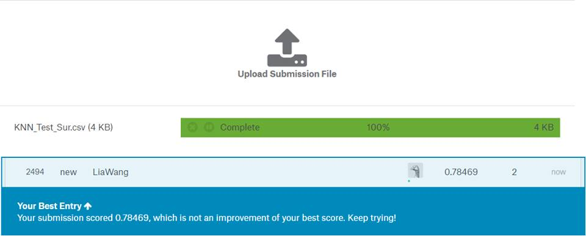

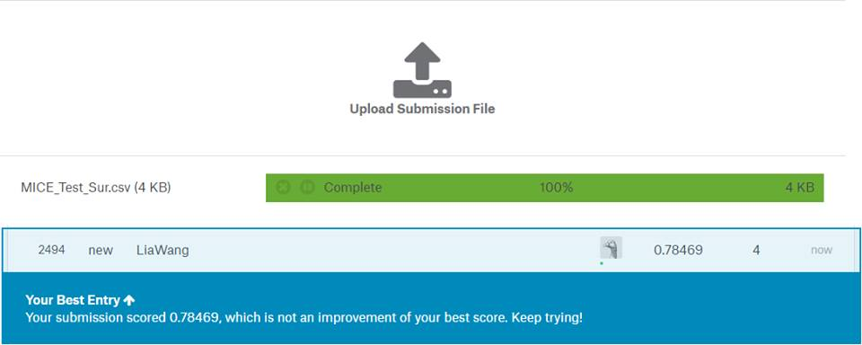

## 6. 總結

從本次資料分析實戰流程，可以整理出以下操作變因：

- NA填補的方式（資料整理）
  - 統計數字
  - KNN
  - MICE
    - 選擇哪些變數用以建模
  - （其他）
- 預測模型之建立
  - 使用哪些資料給電腦建模。  
    如果那些資料需要整理，又以那些方式填補NA
  - 使用哪個建模方式
    - 決策樹（Decision tree）
    - 隨機森林模型（Random forest）
    - （其他）
      - 每個模型又各自有不同的變數可選擇…

觀察KNN_Test與MICE_Test中Age在填補NA後，各項統計數值可推知兩者在本次整理資料後結果相似。而Age又是NA值最多、最可能影響資料結構在整理後之變數。所以或許由於此緣故，本次兩組資料整理方法的預測結果完全相同！